# Cointegration

FIN 3380

## Step 1. Load the prices of individual stocks

```r
setwd("C:/Users/siche/Documents/teaching/Introduction to Financial Data Analysis/L5")
require(dplyr,quietly = T,warn.conflicts = F)
require(tidyr,quietly = T,warn.conflicts = F)
require(urca,quietly = T,warn.conflicts = F)

load("crsp.sample.RData")
head(crsp.sample)
```

```
##   permno       date          ret   prc shrout
## 1  11600 2010-01-04  0.004549436 35.33 147000
## 2  11600 2010-01-05 -0.011887969 34.91 147000
## 3  11600 2010-01-06  0.006588357 35.14 147000
## 4  11600 2010-01-07  0.013090469 35.60 147000
## 5  11600 2010-01-08  0.000000000 35.60 147000
## 6  11600 2010-01-11  0.012921430 36.06 147000
```

#### Calculate the log of prices

```r
crsp.sample = crsp.sample %>%
  mutate(logprice = log(abs(prc))) %>%
  select(permno,date,logprice) %>% na.omit()
head(crsp.sample)
```

```
##   permno       date logprice
## 1  11600 2010-01-04 3.564733
## 2  11600 2010-01-05 3.552773
## 3  11600 2010-01-06 3.559340
## 4  11600 2010-01-07 3.572346
## 5  11600 2010-01-08 3.572346
## 6  11600 2010-01-11 3.585184
```

## Step 2. Construct the 45 (10*9/2) potential pairs and examine the cointegration for one pair as an example.

#### Tasks are seperated based on different pairs of stocks

#### First create different pairs of stocks use combn(x,m), which generate all combinations of n elements, take m at a time.

```r
permno = unique(crsp.sample$permno)
comb = data.frame(t(combn(permno, 2)))
comb
```

```
##       X1    X2
## 1  11600 13610
## 2  11600 39731
## 3  11600 79089
## 4  11600 83148
## 5  11600 85459
## 6  11600 86091
## 7  11600 89509
## 8  11600 90029
## 9  11600 91421
## 10 13610 39731
## 11 13610 79089
## 12 13610 83148
## 13 13610 85459
## 14 13610 86091
```

[output cut: 31 more lines]

#### Examine the cointegration for one pair as an example.

```r
t1.name = comb$X1[1]
t2.name = comb$X2[1]
t1.name;t2.name;
```

```
## [1] 11600
```

```
## [1] 13610
```

```r
df = crsp.sample
df = df[which(df$permno %in% c(t1.name,t2.name)),]
df = spread(df,permno,logprice)
head(df)
```

```
##         date    11600    13610
## 1 2010-01-04 3.564733 2.898119
## 2 2010-01-05 3.552773 2.869035
## 3 2010-01-06 3.559340 2.854169
## 4 2010-01-07 3.572346 2.867331
## 5 2010-01-08 3.572346 2.875258
## 6 2010-01-11 3.585184 2.883683
```

```r
df = df[complete.cases(df),]
ts = df[,c(2,3)]
head(ts)
```

```
##      11600    13610
## 1 3.564733 2.898119
## 2 3.552773 2.869035
## 3 3.559340 2.854169
## 4 3.572346 2.867331
## 5 3.572346 2.875258
## 6 3.585184 2.883683
```

#### Use the function ca.jo() from library(urca) can test cointegration for a matrix with each column a time series.

```r
tmp = ca.jo(ts)
j = summary(tmp)
j
```

```
##
## ######################
## # Johansen-Procedure #
## ######################
##
## Test type: maximal eigenvalue statistic (lambda max) , with linear trend
##
## Eigenvalues (lambda):
## [1] 0.003672699 0.001101594
##
## Values of teststatistic and critical values of test:
##
##          test 10pct  5pct  1pct
## r <= 1 | 2.49  6.50  8.18 11.65
## r = 0  | 8.32 12.91 14.90 19.19
##
## Eigenvectors, normalised to first column:
## (These are the cointegration relations)
##
##           X11600.l2  X13610.l2
## X11600.l2  1.000000  1.0000000
## X13610.l2 -3.076403 -0.1632867
##
## Weights W:
## (This is the loading matrix)
##
##             X11600.l2     X13610.l2
## X11600.d 0.0006508051 -0.0020229508
## X13610.d 0.0022825994  0.0001125819
```

#### The row r=0: H0 is no cointegration.

#### The row r<=1: H0 is cointegration exist.

#### j@teststat gives the test statistics

#### j@cval gives the critical values at different probability

#### If j@teststat>j@cval, cointegration is detected.

```r
r = data.frame(stock1 = t1.name, stock2 = t2.name,
                 stat = j@teststat[2])
r
```

```
##   stock1 stock2     stat
## 1  11600  13610 8.322939
```

```r
r[, c("pct10", "pct5", "pct1")] = j@cval[2, ]
r
```

```
##   stock1 stock2     stat pct10 pct5  pct1
## 1  11600  13610 8.322939 12.91 14.9 19.19
```

#### Wrap up the above task to a user defined function, so that it can be used by foreach in later steps.

```r
jtest = function(t1.name, t2.name, df) {
  df = df[which(df$permno %in% c(t1.name,t2.name)),]
  df = spread(df,permno,logprice)
  df = df[complete.cases(df),]
  ts = df[,c(2,3)]
  j = summary(ca.jo(ts))
  r = data.frame(stock1 = t1.name, stock2 = t2.name,
                 stat = j@teststat[2])
  r[, c("pct10", "pct5", "pct1")] = j@cval[2, ]
  return(r)
}

jtest(t1.name = t1.name ,t2.name = t2.name,df = crsp.sample)
```

```
##   stock1 stock2     stat pct10 pct5  pct1
## 1  11600  13610 8.322939 12.91 14.9 19.19
```

## Step 3. Use foreach to generate the stats for all pairs

#### Load packages

##### * The lapply function from base R apply a function to each element of a list and return a list

##### * require() is similar to library(), but can be used within other functions.

##### * character.only is a logical indicating whether package or help can be assumed to be character strings.

```r
pkgs = list("doParallel", "foreach")
lapply(pkgs, require, character.only = T, quietly = T, warn.conflicts = T)
```

```
## [[1]]
## [1] TRUE
##
## [[2]]
## [1] TRUE
```

#### The foreach package works together with doParallel to work on a task on each object in foreach. With %dopar%, the task is excuted parallelly on each object so that its faster for large project.

##### * detectCores() can tell us the maximum amount we can seperate our tasks.

```r
detectCores(all.tests = FALSE, logical = TRUE)
```

```
## [1] 4
```

##### * registerDoParallel(cores) tell the computer how many tasks to perform at the same time.

```r
registerDoParallel(cores = 4)
```

#### Parallelly computing ….

```r
stat = foreach(i = 1:nrow(comb),
               .combine = rbind,
               .packages = c("urca","tidyr")) %dopar%
               jtest(as.character(comb[i, 1]), as.character(comb[i, 2]),df = crsp.sample)
```

#### foreach() like for loop

##### * Starting with an iterater i

##### * .combine: how does the results get together. By default, list, could use rbind, cbind

##### * .packages are necessary. Always need to load the necessary package for each worker.

##### * %dopar% is key for parallel processing, followed by the task send to each worker.

##### Note: recursive calculation is not possible on parallel processing.

#### Organise the result, sort the test statistics from largest to smallest.

```r
head(stat)
```

```
##   stock1 stock2      stat pct10 pct5  pct1
## 1  11600  13610  8.322939 12.91 14.9 19.19
## 2  11600  39731  3.082622 12.91 14.9 19.19
## 3  11600  79089 10.715883 12.91 14.9 19.19
## 4  11600  83148  4.327521 12.91 14.9 19.19
## 5  11600  85459  6.022526 12.91 14.9 19.19
## 6  11600  86091  6.609657 12.91 14.9 19.19
```

```r
stat = stat[order(-stat$stat), ]
head(stat)
```

```
##    stock1 stock2      stat pct10 pct5  pct1
## 19  39731  83148 20.826033 12.91 14.9 19.19
## 26  79089  85459 12.143991 12.91 14.9 19.19
## 27  79089  86091 11.229224 12.91 14.9 19.19
## 21  39731  86091 10.743220 12.91 14.9 19.19
## 3   11600  79089 10.715883 12.91 14.9 19.19
## 14  13610  86091  9.762978 12.91 14.9 19.19
```

## Step 4. Select cointegrated pairs

#### Select out the cointegrated pairs and prepare their prices for trading.

```r
copair= stat %>% dplyr::filter(stat>pct1) %>% mutate_at(vars(stock1,stock2), as.character)
head(copair)
```

```
##   stock1 stock2     stat pct10 pct5  pct1
## 1  39731  83148 20.82603 12.91 14.9 19.19
```

#### Prepare the prices for the cointegrated pair for the construction of trading strategy.

```r
goodpair = crsp.sample %>% filter(permno %in% c(copair$stock1,copair$stock2))
head(goodpair)
```

```
##   permno       date  logprice
## 1  39731 2010-01-04 0.4885800
## 2  39731 2010-01-05 0.5538851
## 3  39731 2010-01-06 0.6418539
## 4  39731 2010-01-07 0.6931472
## 5  39731 2010-01-08 0.7129498
## 6  39731 2010-01-11 0.6881346
```

```r
goodpair = spread(goodpair,permno,logprice)
```

## Step 5. Estimate the hedge ratio using linear regression, and get the spread between two stocks

```r
est = lm(goodpair[,2]~goodpair[,3],data=goodpair)
summary(est)$coef
```

```
##                Estimate Std. Error   t value Pr(>|t|)
## (Intercept)   -3.365973 0.06272395 -53.66328        0
## goodpair[, 3]  2.193866 0.02662189  82.40833        0
```

```r
goodpair$spread = est$residuals
```

#### Visualise the residual process

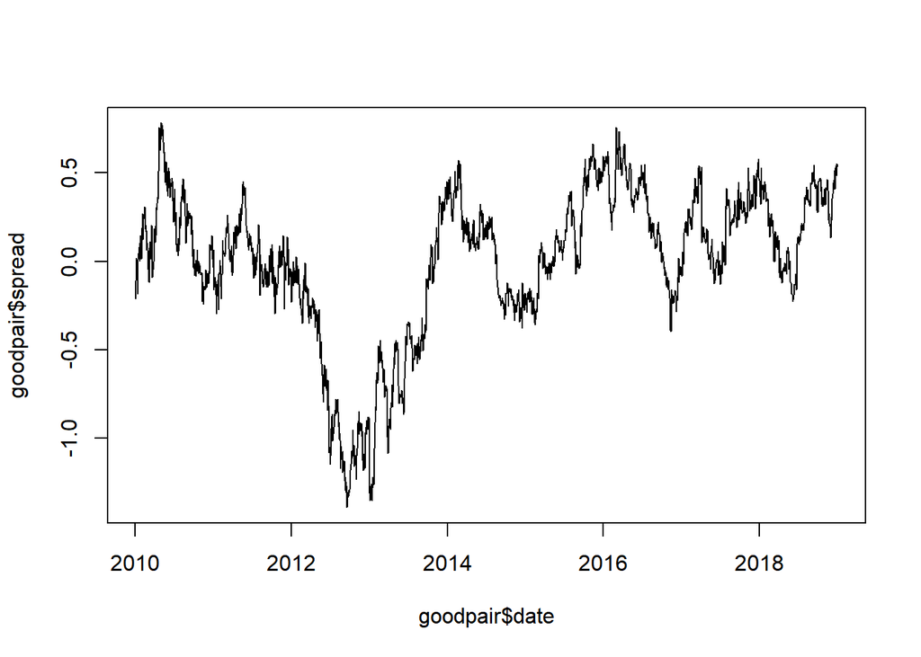

```r
plot(goodpair$spread~goodpair$date,type='l')
```

#### Check the spread is no longer has unit root

```r
require(fUnitRoots)
adfTest(goodpair$spread)
```

```
##
## Title:
##  Augmented Dickey-Fuller Test
##
## Test Results:
##   PARAMETER:
##     Lag Order: 1
##   STATISTIC:
##     Dickey-Fuller: -2.6279
##   P VALUE:
##     0.01
##
## Description:
##  Sun Dec 01 19:04:37 2019 by user: siche
```

## Step 6. Create buy sell signals and calculate returns

#### Assume the spread is is Gaussian distributed. That is

$$Spread_t\sim N(0,\sigma^2)$$

##### * Calculate the standard deviation of the spread.

```r
sd.spread = sd(goodpair$spread)
```

#### If buy 1 share of Y and sell $\beta$ shares of X, the portfolio value at t is

$$log(Y_t)-\beta \times log(X_t) = spread_t + \alpha$$

#### If buy 1 share of Y and sell $\beta$ shares of X, the portfolio value at t+1 is

$$log(Y_{t+1})-\beta \times log(X_{t+1}) = spread_{t+1} + \alpha$$

#### The return from t to t+1 is

$$spread_{t+1}-spread_{t}$$

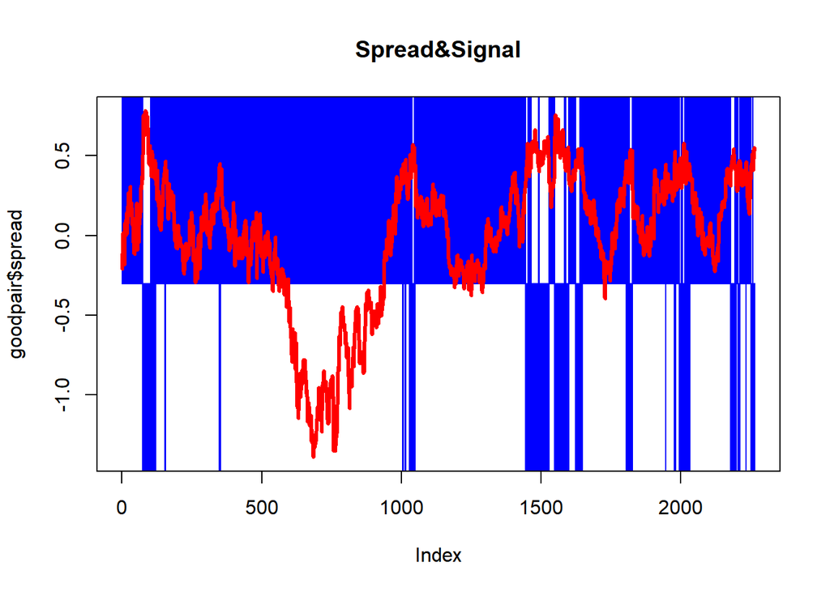

```r
goodpair = goodpair %>% mutate(signal = ifelse(spread>sd.spread,-1,1))
barplot(goodpair$signal,col="blue",
        space = 0,
        border = "blue",
        xaxt="n",yaxt="n",xlab="",ylab="")
par(new=TRUE)
plot(goodpair$spread,type='l',col='red',lwd=3,main='Spread&Signal')
```

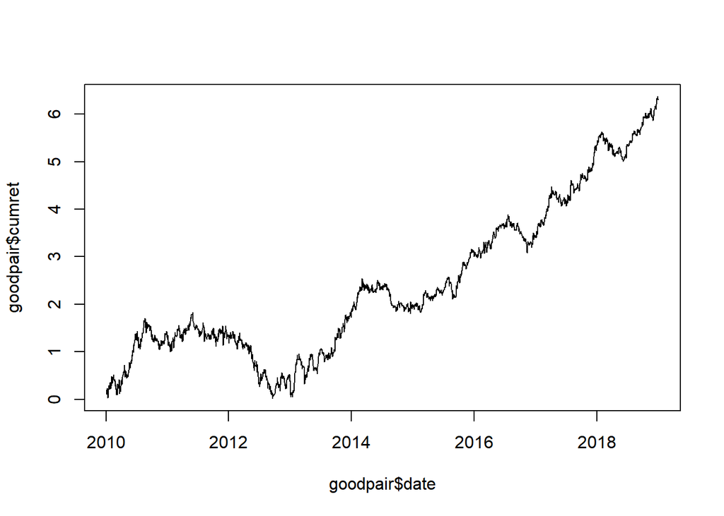

```r
goodpair = goodpair %>% arrange(date) %>%
  mutate(lag.signal = dplyr::lag(signal,1),
         ret.buy.y = spread-dplyr::lag(spread,1)) %>%
  mutate(ret.signal = lag.signal*ret.buy.y) %>%
  na.omit() %>% mutate(cumret = cumsum(ret.signal))
plot(goodpair$cumret~goodpair$date,type='l')
```

## Step 8. Model the spread as AR(1) process.

#### $$Spread_t = \theta Spread_{t-1} + \epsilon_t$$

#### With $\epsilon_t\sim N(0,\sigma^2)$, the intercept is 0 since the $Spread_t$ is constructed from regression.

##### * Recursively make 1-step forcast of the $E(Spread_{t+1}|F_t)$: $E(Spread_{t+1}|F_t) = \theta\times Spread_t$

##### * Remember: The 1-step forecast error of AR(1) is $\sigma$, that is $Var(Spread_{t+1}-E(Spread_{t+1}|F_t)) = \sigma^2$

#### Reconstruct the trading strategy: If the realised spread is much higher than the predicted spread, Y is too expensive/X is too cheap. Sell Y and buy X.

##### * If $Spread_{t} - E(Spread_t|F_{t_1})>\sigma$, buy $\beta$ shares of X for and sell 1 share of Y, instead, buy 1 share of Y and sell $\beta$ shares of X.

##### * Estimate the AR(1) model

```r
ar1 = arima(goodpair$spread,c(1,0,0),fixed=c(NA,0))
ar1
```

```
##
## Call:
## arima(x = goodpair$spread, order = c(1, 0, 0), fixed = c(NA, 0))
##
## Coefficients:
##          ar1  intercept
##       0.9915          0
## s.e.  0.0027          0
##
## sigma^2 estimated as 0.003021:  log likelihood = 3352.1,  aic = -6700.21
```

##### The variance of the error term is given in the sigma2 field.

```r
err = sqrt(ar1$sigma2)
```

##### Construct the signals

```r
goodpair.ar1 = goodpair %>% arrange(date) %>%
  mutate(pred.spread = spread*ar1$coef[1],
         diff = spread-dplyr::lag(pred.spread,1),
         signal = ifelse(diff>err,-1,1))
head(goodpair.ar1)
```

```
##         date     39731    83148       spread signal lag.signal
## 1 2010-01-05 0.5538851 1.835776 -0.107589114     NA          1
## 2 2010-01-06 0.6418539 1.830980 -0.009098127     -1          1
## 3 2010-01-07 0.6931472 1.842136  0.017721462      1          1
## 4 2010-01-08 0.7129498 1.853168  0.013320361      1          1
## 5 2010-01-11 0.6881346 1.850028 -0.004606667      1          1
## 6 2010-01-12 0.6151857 1.838961 -0.053275414      1          1
##      ret.buy.y   ret.signal    cumret  pred.spread         diff
## 1  0.103460303  0.103460303 0.1034603 -0.106670257           NA
## 2  0.098490987  0.098490987 0.2019513 -0.009020425  0.097572130
## 3  0.026819589  0.026819589 0.2287709  0.017570113  0.026741887
## 4 -0.004401101 -0.004401101 0.2243698  0.013206599 -0.004249753
## 5 -0.017927028 -0.017927028 0.2064427 -0.004567324 -0.017813266
## 6 -0.048668747 -0.048668747 0.1577740 -0.052820419 -0.048708089
```

##### Calculate the returns as before.

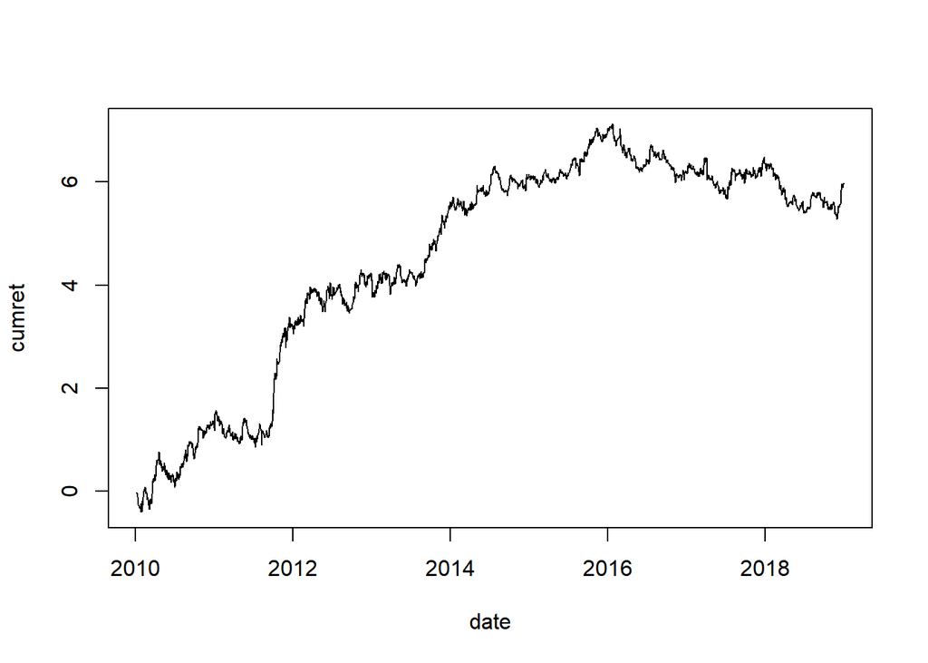

```r
goodpair.ar1 = goodpair.ar1 %>%
  mutate(signal.lag = dplyr::lag(signal,1),
         ret.buy.y = spread-dplyr::lag(spread,1),
         ret.signal = signal.lag*ret.buy.y) %>%
  na.omit() %>% mutate(cumret = cumsum(ret.signal))
with(goodpair.ar1,plot(cumret~date,type='l'))
```

#### Again, assume the $Spread_t$ is Gaussian process.

```r
est = lm(goodpair[,2]~goodpair[,3],data=goodpair[1:1100,])
summary(est)
```

```
##
## Call:
## lm(formula = goodpair[, 2] ~ goodpair[, 3], data = goodpair[1:1100,
##     ])
##
## Residuals:
##      Min       1Q   Median       3Q      Max
## -1.39027 -0.16672  0.07225  0.30184  0.78232
##
## Coefficients:
##               Estimate Std. Error t value Pr(>|t|)
## (Intercept)   -3.36494    0.06277  -53.61   <2e-16 ***
## goodpair[, 3]  2.19347    0.02664   82.34   <2e-16 ***
## ---
## Signif. codes:  0 '***' 0.001 '**' 0.01 '*' 0.05 '.' 0.1 ' ' 1
##
## Residual standard error: 0.4232 on 2261 degrees of freedom
## Multiple R-squared:  0.7499, Adjusted R-squared:  0.7498
## F-statistic:  6780 on 1 and 2261 DF,  p-value: < 2.2e-16
```

#### Calcuate the spread using the estimated model

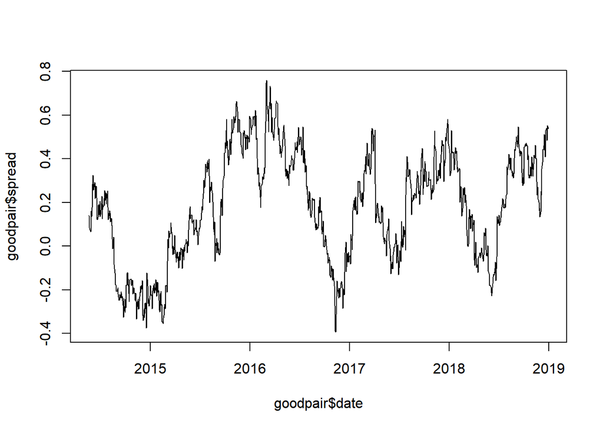

```r
goodpair$spread = goodpair[,2]-
  (est$coefficients[1] + goodpair[,3]*est$coefficients[2])
goodpair = goodpair[1101:nrow(goodpair),]
plot(goodpair$spread~goodpair$date,type='l')
```

```r
adfTest(goodpair$spread)
```

```
##
## Title:
##  Augmented Dickey-Fuller Test
##
## Test Results:
##   PARAMETER:
##     Lag Order: 1
##   STATISTIC:
##     Dickey-Fuller: -2.1524
##   P VALUE:
##     0.03193
##
## Description:
##  Sun Dec 01 19:04:38 2019 by user: siche
```

```r
sd.spread.new = sd(goodpair$spread)
```

#### Generate signals and calculate the returns

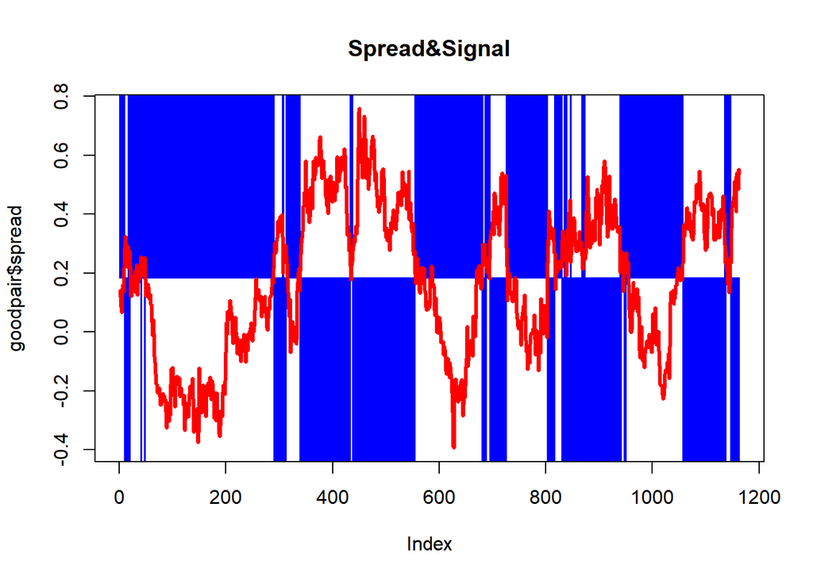

```r
goodpair = goodpair %>% mutate(signal = ifelse(spread>sd.spread.new,-1,1))
barplot(goodpair$signal,col="blue",space = 0,border =
          "blue",xaxt="n",yaxt="n",xlab="",ylab="")
par(new=TRUE)
plot(goodpair$spread,type='l',col='red',lwd=3,main='Spread&Signal')
```

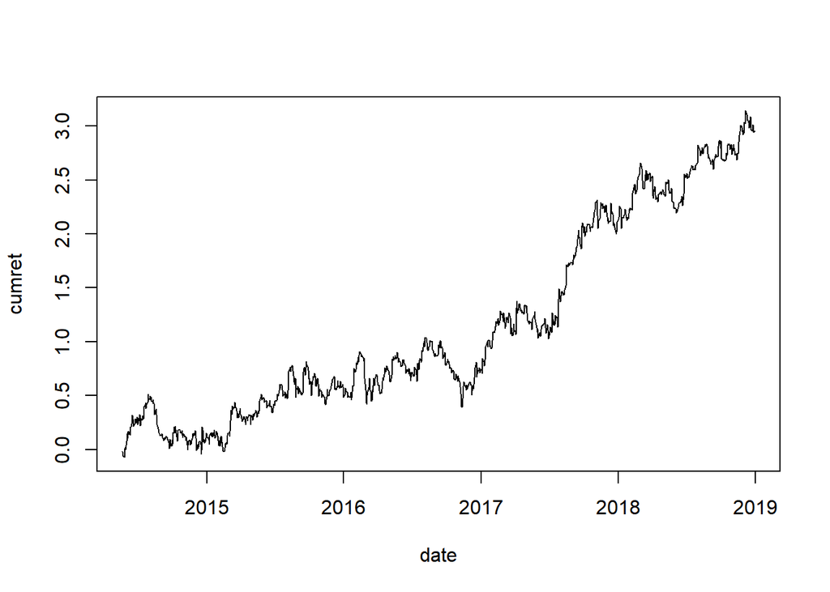

```r
goodpair = goodpair %>% arrange(date) %>%
  mutate(signal.lag = dplyr::lag(signal,1),
         ret.buy.y = spread-dplyr::lag(spread,1),
         ret.signal = signal.lag*ret.buy.y) %>%
  na.omit() %>% mutate(cumret = cumsum(ret.signal))
with(goodpair,plot(cumret~date,type='l'))
```

```r
goodpair = goodpair %>% arrange(date) %>%
  mutate(dd = (cumret+1-cummax(cumret+1))/cummax(cumret+1))
sharpe.ratio = mean(goodpair$ret.signal,na.rm=T)/sd(goodpair$ret.signal,na.rm=T)*sqrt(252)
sharpe.ratio
```

```
## [1] 0.8772286
```

```r
head(goodpair)
```

```
##         date    39731    83148     spread signal lag.signal    ret.buy.y
## 1 2014-05-21 2.140066 2.455306 0.11938264      1          1 -0.019809201
## 2 2014-05-22 2.134166 2.468100 0.08542102      1          1 -0.033961621
## 3 2014-05-23 2.164472 2.485740 0.07703344      1          1 -0.008387583
## 4 2014-05-27 2.196113 2.504709 0.06706530      1          1 -0.009968134
## 5 2014-05-28 2.224624 2.480731 0.14817093      1          1  0.081105625
## 6 2014-05-29 2.218116 2.472328 0.16009575      1          1  0.011924821
##     ret.signal       cumret signal.lag          dd
## 1 -0.019809201 -0.019809201          1  0.00000000
## 2 -0.033961621 -0.053770823          1 -0.03464797
## 3 -0.008387583 -0.062158406          1 -0.04320506
## 4 -0.009968134 -0.072126540          1 -0.05337465
## 5  0.081105625  0.008979085          1  0.00000000
## 6  0.011924821  0.020903907          1  0.00000000
```

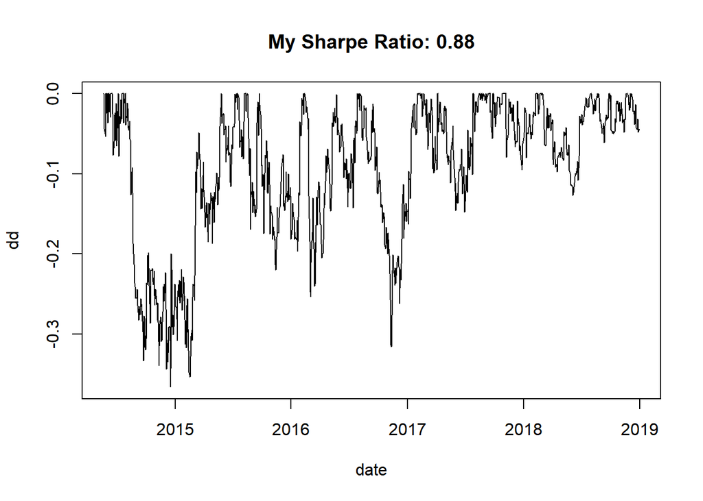

```r
plot(dd~date,type='l',data = goodpair,
     main=paste0("My Sharpe Ratio: ",round(sharpe.ratio,2)))
```